# Week 7 Slides

## Interpreting Gene Expression

## Gene Annotations

- Individual gene studies can characterize:
  - function
  - localization
  - structure
  - interactions
  - chemical properties
  - dynamics
- Genes are *annotated* with these properties via different databases
- Some annotations consolidated into centralized metadatabases
- e.g. `genecards.org`

## Example Gene Card

[figure not shown]

* https://www.genecards.org/cgi-bin/carddisp.pl?gene=APOE&keywords=APOE

## Gene Ontology (GO)

- *Ontology*: a controlled vocabulary of biological concepts
- The Gene Ontology (GO): a set of *terms* that describes what genes are, do, etc
- Each GO Term has a code like `GO:NNNNNNN`, e.g. `GO:0019319`
- GO Terms subdivided into three *namespaces*:
  - Biological Process (BP) - pathways, etc
  - Molecular Function (MF) - enzymatic activity, DNA binding, etc
  - Cellular Component (CC) - nucleus, cell membrane, etc
- Terms within each namespace are hierarchical, form a directed acyclic graph (DAG)

## Gene Ontology

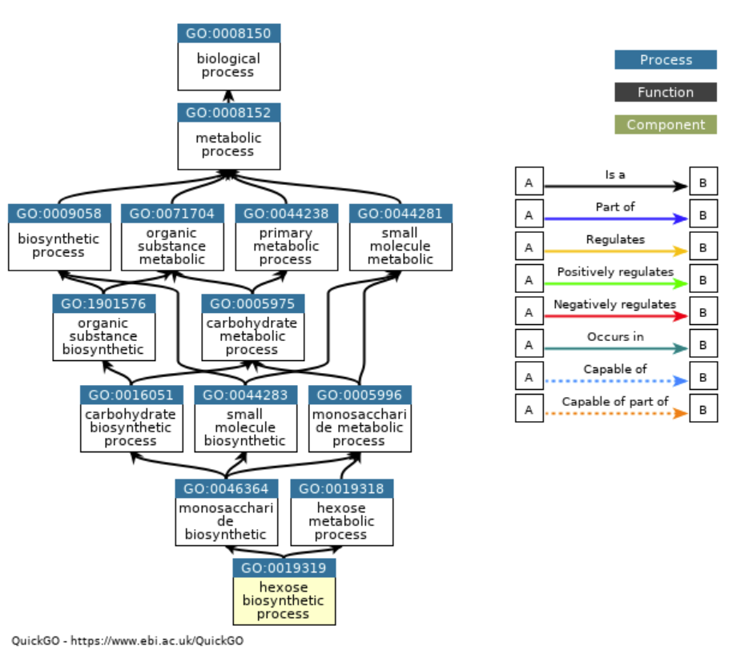

## Example GO Term

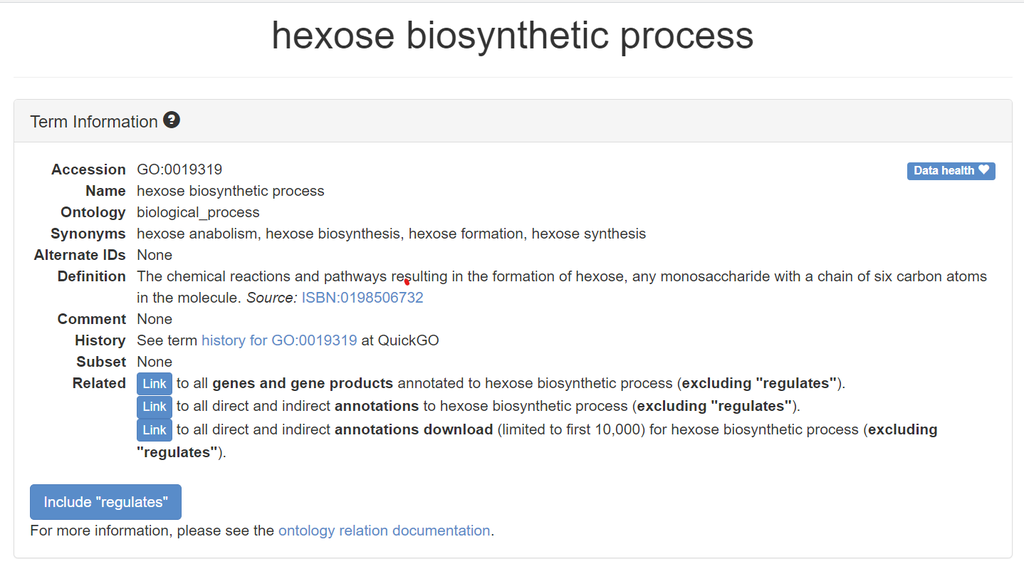

- http://amigo.geneontology.org/amigo/term/GO:0019319

## GO Annotation

- GO Terms can apply to genes from all biological systems
- The GO itself does not contain gene annotations
- *GO annotations* are provided/maintained separately for each organism
- A gene may be annotated to many GO terms
- A GO term may be annotated to many genes

## GO Annotation

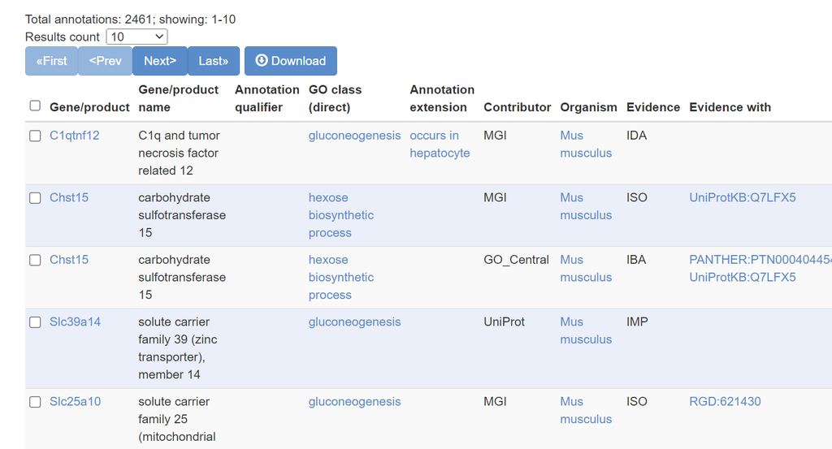

## Individual to Many Genes

- High throughput gene expression studies implicate many genes
- What biological processes are implicated by a differential expression analysis?
- Idea: examine the annotations of all implicated genes and look for patterns

## Gene Sets

- Genes can be organized by different attributes:
  - biochemical function, e.g. enzymatic activity
  - biological process, e.g. pathways
  - localization, e.g. nucleus
  - disease association
  - chromosomal locus
  - defined by differential expression studies!
  - any other reasonable grouping
- A *gene set* is a group of genes related in one way or another
- e.g. all genes annotated to GO Term GO:0019319 - hexose biosynthetic process

## Gene Set Databases

- Gene set database: a collection of gene sets
- Different databases organize/maintain different sets of genes for different purposes

## GO Annotations

- Available at geneontology.org for many species
- Programmatic access as well
- Provided in tab-delimited GAF (GO Annotation Format) files

## KEGG

- Kyoto Encyclopedia of Genes and Genomcs
- “Gold standard” for curated pathways
- Highly detailed, validated gene sets with gene interaction information
- https://www.genome.jp/kegg/pathway.html

## KEGG

[figure not shown]

## KEGG: Huntington’s Disease

[figure not shown]

## KEGG: Huntington’s Disease

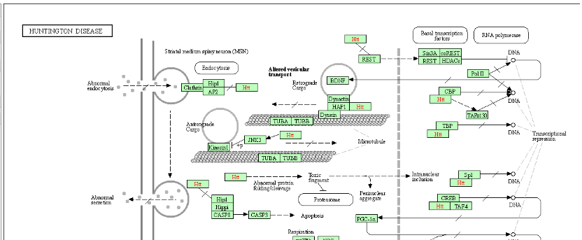

## MSigDB

- Molecular Signatures Data Base
- Originally, gene sets associated with cancer
- Contains 9 collections of gene sets:
  - H - well defined biological states/processes
  - C1 - positional gene sets
  - C2 - curated gene sets
  - C3 - regulatory targets
  - C4 - computational gene sets
  - C5 - GO annotations
  - C6 - oncogenic signatures
  - C7 - immunologic signatures
  - C8 - cell type signatures

## `.gmt` - Gene Set File Format

- `.gmt` - Gene Matrix Transpose
- Defined by Broad Institute for use in its GSEA software
- Contains gene sets, one per line
- Tab-separated format with columns:
  - 1st column: Gene set name
  - 2nd column: Gene set description (often blank)
  - 3rd and on: gene identifiers for genes in set

## GMT File

[figure not shown]

## GMT Files in R

```r
library('GSEABase')
hallmarks_gmt <- getGmt(con='h.all.v7.5.1.symbols.gmt')
hallmarks_gmt
## GeneSetCollection
##   names: HALLMARK_TNFA_SIGNALING_VIA_NFKB, HALLMARK_HYPOXIA, ..., HALLMARK_PANCREAS_BETA_CELLS (50 total)
##   unique identifiers: JUNB, CXCL2, ..., SRP14 (4383 total)
##   types in collection:
##     geneIdType: NullIdentifier (1 total)
##     collectionType: NullCollection (1 total)
```

## Gene Set Enrichment Analysis

- Compare
  - a gene list of interest (e.g. DE gene list) with
  - a gene set (e.g. genes annotated to `GO:0019319`)
- Are the genes in our gene list have more similarity to the genes in the gene set than we expect by chance?

## Gene Set Enrichment Flavors

- Over-representation: does our gene list overlap a gene set more than expected by chance?
- Rank-based: are the gene in a gene set more increased/decreased in our gene list than expected by chance?

## Over-representation

- Useful with a list of “genes of interest” e.g. DE genes at FDR < 0.05
- Compute overlap with genes in a gene set
- Is the overlap greater than we would expect by chance?

## Hypergeometric/Fisher’s Exact Test

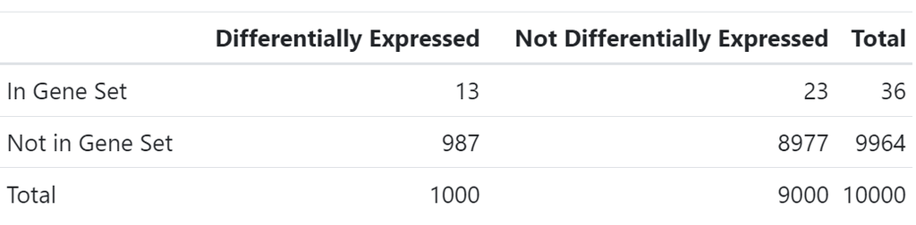

## Hypergeometric/Fisher’s Exact Test

```r
contingency_table <- matrix(c(13, 987, 23, 8977), 2, 2)
fisher_results <- fisher.test(contingency_table, alternative='greater')
fisher_results
##
##  Fisher's Exact Test for Count Data
##
## data:  contingency_table
## p-value = 2.382e-05
## alternative hypothesis: true odds ratio is greater than 1
## 95 percent confidence interval:
##  2.685749      Inf
## sample estimates:
## odds ratio
##   5.139308
```

## Rank Based: GSEA

- Inputs:
  - *all* genes irrespective of significance, ranked by a statistic e.g. log2 fold change
  - gene set database
- Examines whether genes in each gene set are more highly or lowly ranked than expected by chance
- Computes a Kolmogorov-Smirnov test to determine signficance
- Produces *Normalized Enrichment Score*
  - Positive if gene set genes are at the top of the sorted list
  - Negative if at bottom
- Official software: standalone JAVA package

## Rank Based: GSEA

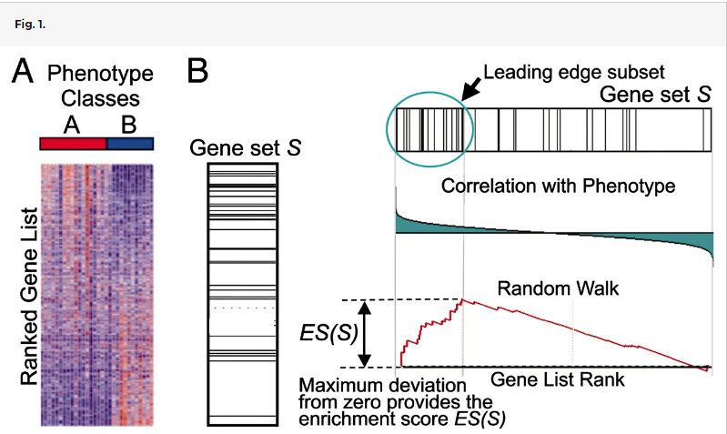

## fgsea

- [fgsea](https://bioconductor.org/packages/release/bioc/html/fgsea.html) package implements the GSEA preranked algorithm in R
- Requires
  - List of ranked genes
  - Database of gene sets

## Statistical Distributions

## Statistical Distributions

- Statistics was created to quantify uncertainty
- Statistics provides tools to separate *signal* from *noise*
- The *statistical distribution* is a tool we can use to estimate and quantify uncertainty

## Random Variables

- A random variable is an object or quantity which:
  - depends upon random events
  - can have samples drawn from it
- Each random variable has a potential set of possible outcomes (e.g. a real number, an integer, a category, a mathematical tree)
- Each possible outcome has some probability of appearing, relative to other outcomes
- The complete mapping of relative probabilities to outcomes for a random variable forms a *distribution*

## Random Variable Examples

- a six-sided die
- a coin
- transcription of a gene

## Random Variable Notation

- Usually notated as capital letters, like \(X,Y,Z,\) etc
- A sample drawn from a random variable is usually notated as a lowercase of the same letter
- e.g. \(x\) is a sample drawn from the random variable \(X\)
- Distribution of random variable usually described like
  - “\(X\) follows a binomial distribution”
  - “\(Y\) is a normally distributed random variable”
- Probability of a random variable taking one of its possible values: \(P(X = x)\)

## Statistical Distribution Basics

- A statistical distribution is a function that maps **the possible values for a variable to how often they occur**
- Alternatively, distribution describes the probability of seeing a single value, or a range of values, relative to all other possible values

```r
tibble(
  x = seq(-4,4,by=0.1),
  `Probability Density`=dnorm(x,0,1)
) %>%
  ggplot(aes(x=x,y=`Probability Density`)) +
  geom_line() +
  labs(title="Probability Density Function for a Normal Distribution")
```

## Normal Distribution

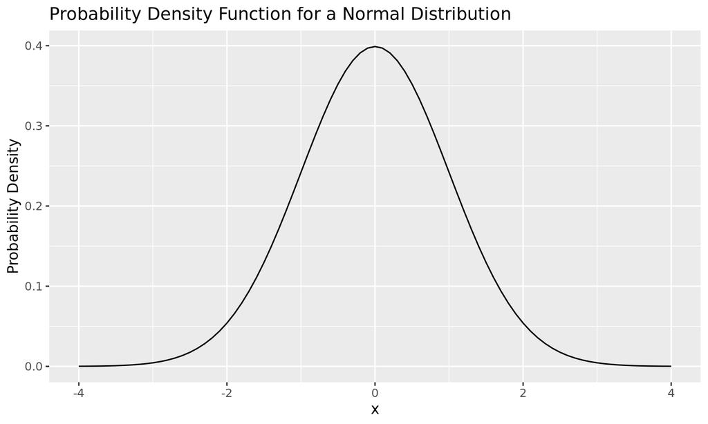

## Probability Density Functions

- *probability density function* (PDF) defines probability associated with every possible value of a random variable
- Many PDFs have a closed mathematical form
- The PDF for the normal distribution is:

\[ P(X = x|\mu,\sigma) = \frac{1}{\sigma\sqrt{2\pi}}e^{\frac{-(x-\mu)^2}{2\sigma}} \]

## PDFs

\[ P(X = x|\mu,\sigma) = \frac{1}{\sigma\sqrt{2\pi}}e^{\frac{-(x-\mu)^2}{2\sigma}} \]

- Notation \(P(X = x|\mu,\sigma)\) - “the probability that the random variable \(X\) takes the value \(x\), given mean \(\mu\) and standard deviation \(\sigma\)”
- Normal distribution is a *parametric distribution* because PDF requires two parameters
- *Non-parametric distributions* do not require parameters, but are determined from data

## Probability Mass Functions

- PDFs only defined for continuous distributions, with infinite possible values
- Discrete distributions have a finite set of possible values
- *Probability mass functions* discrete distribution analog for PDFs

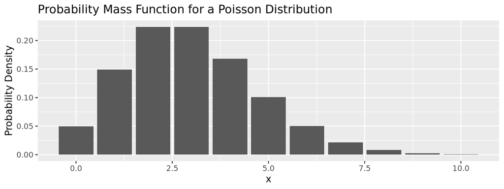

## Note: Probability of Zero

- In probability theory, if a plausible event has a probability of zero, this *does not mean that event can never occur*
- Every specific value in a continuous distribution that supports all real numbers has a probability of zero
- PDF allows us to reason about the *relative likelihood* of observing values in one range of the distribution compared with the others

## Cumulative Distribution Function

- PDF provides the probability density of specific values within the distribution
- Sometimes we want probability of a value being less/greater than or equal to a particular value
- *Cumulative distribution function* (CDF) useful for this purpose

```r
tibble(
  x = seq(-4,4,by=0.1),
  PDF=dnorm(x,0,1),
  CDF=pnorm(x,0,1)
) %>%
  ggplot() +
  geom_line(aes(x=x,y=PDF,color="PDF")) +
  geom_line(aes(x=x,y=CDF,color="CDF"),linetype="dashed")
```

## PDF vs CDF

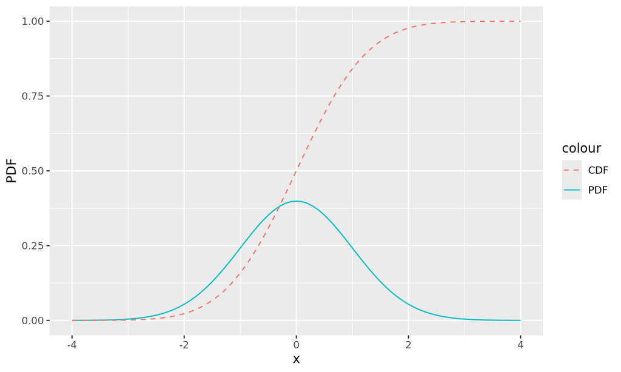

## CDF

- CDF corresponds to area under density curve up to value of \(x\)
- 1 minus that value is the area under the curve greater than that value

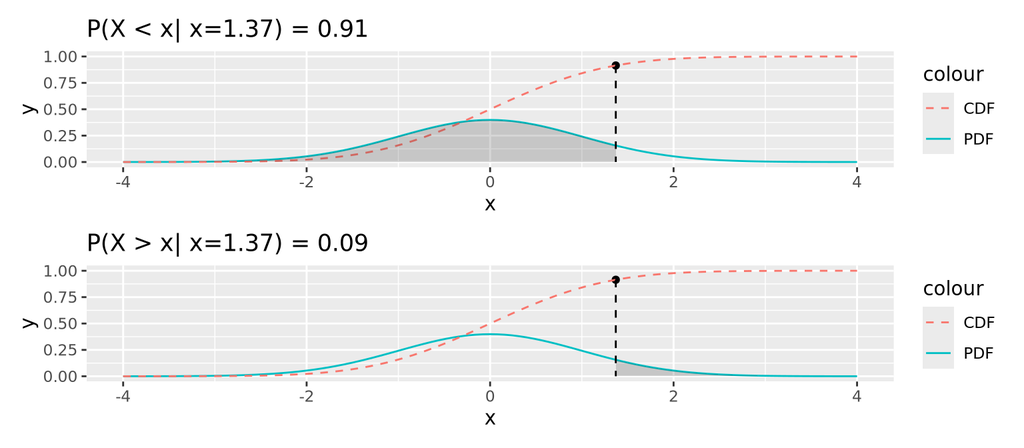

## Generating random samples

- CDF is useful for generating samples from the distribution

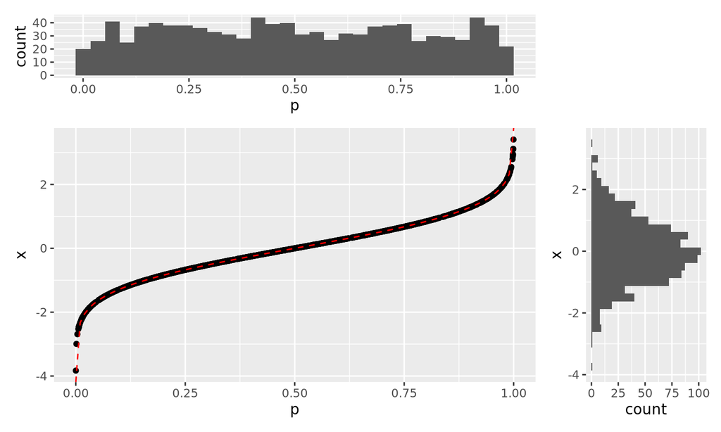

## Distributions in R

- Four key operations we perform with distributions:
1. Calculate probabilities using the PDF
2. Calculate cumulative probabilities using the CDF
3. Calculate the value associated with a cumulative probability
4. Sample values from a parameterized distribution
- Each of these operations has a dedicated function for each different distribution

## Distributions in R

- Each distribution has a family of 4 functions
- Functions end with shortened name of distribution, e.g. `norm` for normal distribution
- Distribution functions prefixed by `d`, `p`, `q`, and `r`, e.g.
1. `dnorm(x, mean=0, sd=1)` - PDF of the normal distribution
2. `pnorm(q, mean=0, sd=1)` - CDF of the normal distribution
3. `qnorm(p, mean=0, sd=1)` - inverse CDF; accepts quantiles between 0 and 1 and returns the value of the distribution for those quantiles
4. `rnorm(n, mean=0, sd=1)` - generate `n` samples from a normal distribution

## Distributions in R

| Distribution | Probability Density Function |
| --- | --- |
| Normal | `dnorm(x,mean,sd)` |
| t Distribution | `dt(x,df)` |
| Poisson | `dpois(n,lambda)` |
| Binomial | `dbinom(x, size, prob)` |
| Negative Binomial | `dnbinom(x, size, prob, mu)` |
| Exponential | `dexp(x, rate)` |
| \(\chi^2\) | `dchisq(x, df)` |

- [many more distributions available](https://www.stat.umn.edu/geyer/old/5101/rlook.html)

## Types of Distributions

## Types of Distributions

- Broadly 2 types of distributions:
  - Continuous - defined for real numbers within a range
  - Discrete - defined for all objects within a set
- A distribution may be either:
  - Theoretical (aka parametric) - defined by a parameterized family of mathematical functions
  - Empirical (aka non-parametric) - defined by data

## Discrete Distributions

- Discrete distributions defined over countable, possibly infinite sets
- Events take one of a set of discrete values
- Common discrete distributions include
  - binomial (e.g. coin flips)
  - multinomial (e.g. dice rolls)
  - Poisson (e.g. number of injuries by horse kick per day)

## Bernoulli random trails

- *Bernoulli trial* = a coin flip
- 2 outcomes with probabilities of \(p\) and \(1-p\)
- Consider a coin flip:
  - \(Pr(X = 0) = Pr(X = 1) = 0.5\) - coin is fair
  - \(Pr(X = 0) = 0.1, Pr(X = 1) = 0.9\) - coin is not fair
- Consider dice roll where we count a 6 as a success and any other roll as failure:
  - \(Pr(X = 0) = 5/6, Pr(X = 1) = 1/6\) - if dice are fair

## Bernoulli random trials

```r
library(statip) # NB: not a base R distribution
# dbern(x, prob, log = FALSE)
# qbern(p, prob, lower.tail = TRUE, log.p = FALSE)
# pbern(q, prob, lower.tail = TRUE, log.p = FALSE)
# rbern(n, prob)
rbern(10, 0.5)
```

## Bernoulli random trials

```r
rbern(10, 0.5)
```

```
##  [1] 0 1 1 1 0 1 0 0 0 0
```

## Binomial distribution

- Consider a sequence of coin flips, where chance of heads is \(p\)
- What is the probability of seeing \(x\) heads out of \(n\) flips?
- The *binomial distribution* models this situation

\[ Pr(X = x|n,p) = {n \choose x} p^x (1-p) ^{(n-x)} \]

## Binomial distribution

```r
# dbinom(x, size, prob, log = FALSE)
# pbinom(q, size, prob, lower.tail = TRUE, log.p = FALSE)
# qbinom(p, size, prob, lower.tail = TRUE, log.p = FALSE)
# rbinom(n, size, prob)
rbinom(10, 10, 0.5)
```

## Binomial distribution

```r
rbinom(10, 10, 0.5)
```

```
##  [1] 5 5 4 5 5 7 5 6 5 3
```

```r
mean(rbinom(1000, 10, 0.5))
```

```
## [1] 5
```

## Geometric distribution

- Consider a sequence of coin flips, where chance of heads is \(p\)
- What is the probability of seeing \(x\) consecutive tails before a head?
- The *geometric distribution* models this situation

\[ Pr(X = x|p) = (1-p)^x p \]

## Geometric distribution

```r
# dgeom(x, prob, log = FALSE)
# pgeom(q, prob, lower.tail = TRUE, log.p = FALSE)
# qgeom(p, prob, lower.tail = TRUE, log.p = FALSE)
# rgeom(n, prob)
rgeom(10, 0.5)
```

## Geometric distribution

```r
rgeom(10, 0.5)
```

```
##  [1] 2 0 1 2 0 2 0 3 0 2
```

## Poisson

- Consider an event that occurs zero or more times in a particular time period at a known constant average rate \(\lambda\)
- What is the probability of seeing \(k\) events in a time period?

\[ Pr(X=k|\lambda) = \frac {\lambda^k e^{-\lambda}} {k!} \]

## Poisson

```r
# dpois(x, lambda, log = FALSE)
# ppois(q, lambda, lower.tail = TRUE, log.p = FALSE)
# qpois(p, lambda, lower.tail = TRUE, log.p = FALSE)
# rpois(n, lambda)
rpois(10, 5)
```

## Poisson

```r
rpois(10, 5)
```

```
##  [1] 3 5 6 5 3 7 3 2 5 8
```

```r
mean(rpois(1000, 5))
```

```
## [1] 4.935
```

## Negative binomial distribution

- Consider a sequence of coin flips, where chance of heads is \(p\)
- What is the probability of seeing \(x\) tails by the time we see the \(r\) heads?

\[ Pr(X = x|r,p) = \frac {x+r-1} {r-1} p^r {(1-p)}^x \]

## Negative binomial distribution

```r
# dnbinom(x, size, prob, mu, log = FALSE)
# pnbinom(q, size, prob, mu, lower.tail = TRUE, log.p = FALSE)
# qnbinom(p, size, prob, mu, lower.tail = TRUE, log.p = FALSE)
# rnbinom(n, size, prob, mu)
rnbinom(10, 10, 0.5)
```

## Negative binomial distribution

```r
# dnbinom(x, size, prob, mu, log = FALSE)
# pnbinom(q, size, prob, mu, lower.tail = TRUE, log.p = FALSE)
# qnbinom(p, size, prob, mu, lower.tail = TRUE, log.p = FALSE)
# rnbinom(n, size, prob, mu)
rnbinom(10, 10, 0.5)
```

```
##  [1] 18  9  7  6  9  9  3 13 12  4
```

## Continuous Distributions

- Continuous distributions defined over infinite, possibly bounded domains, e.g. all real numbers

## Uniform Distribution

- Consider a number in the range \([a, b]\)
- All values in range appear with equal probability

\[ P(X=x|a,b) = \begin{cases} \frac{1}{b-a} & \text{for}\; a \le x \le b, \\ 0 & \text{otherwise} \end{cases} \]

## Uniform Distribution

```r
dunif(x, min = 0, max = 1, log = FALSE)
punif(q, min = 0, max = 1, lower.tail = TRUE, log.p = FALSE)
qunif(p, min = 0, max = 1, lower.tail = TRUE, log.p = FALSE)
runif(n, min = 0, max = 1)
runif(10, min=0, max=10)
```

## Uniform Distribution

```r
runif(10)
```

```
##  [1] 0.09269301 0.04769325 0.49162694 0.06384177 0.74975727 0.06286865
##  [7] 0.59144210 0.85150450 0.80188802 0.49818460
```

```r
mean(runif(1000))
```

```
## [1] 0.495675
```

## Normal Distribution

- *Normal distribution (Gaussian distribution)*

\[ P(X = x|\mu,\sigma) = \frac{1}{\sigma\sqrt{2\pi}}e^{\frac{-(x-\mu)^2}{2\sigma}} \]

## Normal Distribution

```r
# dnorm(x, mean = 0, sd = 1, log = FALSE)
# pnorm(q, mean = 0, sd = 1, lower.tail = TRUE, log.p = FALSE)
# qnorm(p, mean = 0, sd = 1, lower.tail = TRUE, log.p = FALSE)
# rnorm(n, mean = 0, sd = 1)
rnorm(10, mean=10, sd=10)
```

## Normal Distribution

```r
rnorm(10, mean=10, sd=10)
```

```
##  [1]  16.5110731   4.9263930  24.7133656  26.2699361   3.0473640  14.1095811
##  [7]   9.6754010  29.0091827 -13.9826178   0.4802505
```

```r
mean(rnorm(1000, mean=10, sd=10))
```

```
## [1] 10.22659
```

## \(\chi^2\) Distribution

- Models the distribution of \(k\) independent standard normal random variables

\[ P(X=x|k) = \begin{cases} \frac{ x^{\frac{k}{2}-1}e^{-\frac{x}{2}} }{ 2^{\frac{k}{2}}\left ( \frac{k}{2} \right ) }, & x>0;\\ 0, & \text{otherwise} \end{cases} \]$

## \(\chi^2\) Distribution

```r
# dchisq(x, df, ncp = 0, log = FALSE)
# pchisq(q, df, ncp = 0, lower.tail = TRUE, log.p = FALSE)
# qchisq(p, df, ncp = 0, lower.tail = TRUE, log.p = FALSE)
# rchisq(n, df, ncp = 0)
rchisq(10, 10)
```

## \(\chi^2\) Distribution

```r
rchisq(10, 10)
```

```
##  [1] 14.078925 10.028708  5.111300 16.071434  5.637748 10.010057 10.421410
##  [8]  6.069114  7.993634 14.850696
```

```r
mean(rchisq(1000, 10))
```

```
## [1] 9.620238
```

## Empirical Distributions

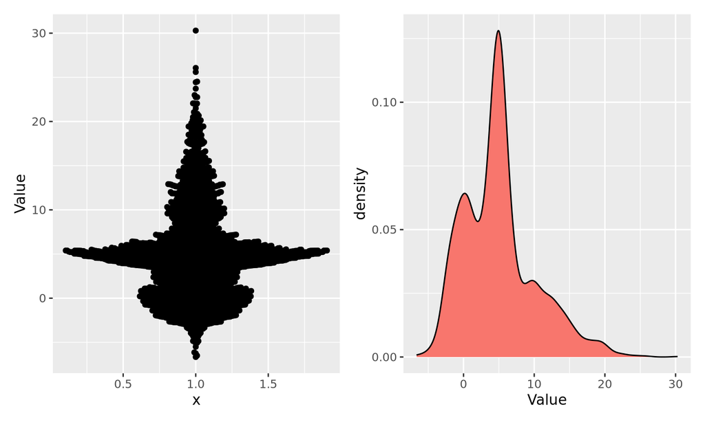

## Empirical CDF

```r
ecdf(d$Value)
```

```
## Empirical CDF
## Call: ecdf(d$Value)
##  x[1:3000] = -6.6546, -6.494, -6.2441,  ..., 26.064,  30.29
```

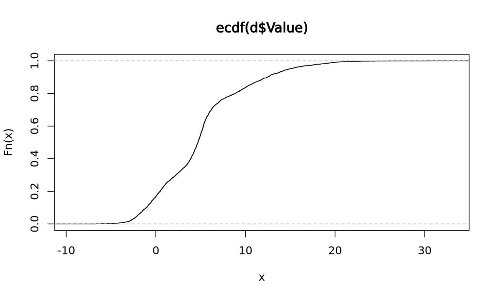

```r
plot(ecdf(d$Value))
```